# Data visualization in practice

# 10 Data visualization in practice

In this chapter, we will demonstrate how relatively simple ggplot2 code can create insightful and aesthetically pleasing plots.

## 10.1 Case study: new insights on poverty

Specifically, in this section, we use data to attempt to answer the following two questions:

1. Is it a fair characterization of today’s world to say it is divided into western rich nations and the developing world in Africa, Asia and Latin America?
2. Has income inequality across countries worsened during the last 40 years?

To answer these questions, we will be using the `gapminder` dataset provided in dslabs.

```r
library(tidyverse)
library(dslabs)
data(gapminder)
gapminder %>% as_tibble()
```

| country | year | infant_mortality | life_expectancy | fertility | population | gdp | continent | region |
| --- | --- | --- | --- | --- | --- | --- | --- | --- |
| Albania | 1960 | 115.40 | 62.87 | 6.19 | 1636054 | NA | Europe | Southern Europe |
| Algeria | 1960 | 148.20 | 47.50 | 7.65 | 11124892 | 1.382815e+10 | Africa | Northern Africa |
| Angola | 1960 | 208.00 | 35.98 | 7.32 | 5270844 | NA | Africa | Middle Africa |
| Antigua and Barbuda | 1960 | NA | 62.97 | 4.43 | 54681 | NA | Americas | Caribbean |
| Argentina | 1960 | 59.87 | 65.39 | 3.11 | 20619075 | 1.083223e+11 | Americas | South America |
| Armenia | 1960 | NA | 66.86 | 4.55 | 1867396 | NA | Asia | Western Asia |
| Aruba | 1960 | NA | 65.66 | 4.82 | 54208 | NA | Americas | Caribbean |
| Australia | 1960 | 20.30 | 70.87 | 3.45 | 10292328 | 9.667786e+10 | Oceania | Australia and New Zealand |
| Austria | 1960 | 37.30 | 68.75 | 2.70 | 7065525 | 5.239270e+10 | Europe | Western Europe |
| Azerbaijan | 1960 | NA | 61.33 | 5.57 | 3897889 | NA | Asia | Western Asia |

[output cut: 990 more lines]

### 10.1.1 Hans Rosling’s quiz

1. Sri Lanka or Turkey
2. Poland or South Korea
3. Malaysia or Russia
4. Pakistan or Vietnam
5. Thailand or South Africa

```r
gapminder %>%
  filter(year == 2015 & country %in% d$country) %>%
  select(country, infant_mortality)
```

[output not shown]

So we make entire comparision:

[output not shown]

In this chapter we see how data visualization helps inform us.

## 10.2 Scatterplots

The reason for this stems from the preconceived notion that the world is divided into two groups: the western world versus the developing world. In order to analyze this world view, our first plot is a scatterplot of life expectancy versus fertility rates:

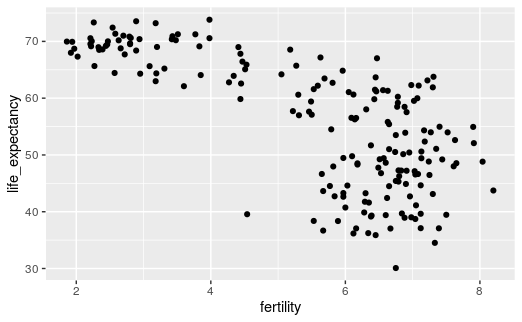

```r
filter(gapminder, year == 1962) %>%
  ggplot(aes(fertility, life_expectancy)) +
  geom_point()
```

Most points fall into two distinct categories: 1. Life expectancy around 70 years and 3 or less children per family. 2. Life expectancy lower then 65 years and more than 5 children per family. To confirm that indeed these countries are from the regions we expect, we can use color to represent continent.

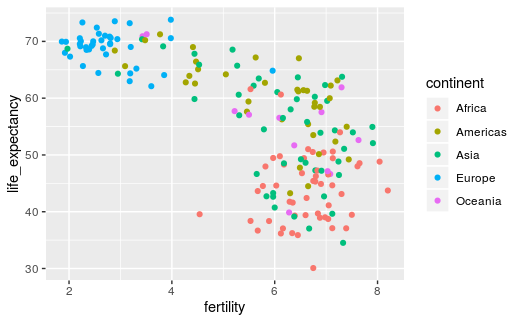

```r
filter(gapminder, year == 1962) %>%
  ggplot( aes(fertility, life_expectancy, color = continent)) +
  geom_point()
```

## 10.3 Faceting

In 1962, “the West versus developing world” view was grounded in some reality. Is this still the case 50 years later?

To make comparisons, however, side by side plots are preferable. In ggplot2, we can achieve this by faceting variables. To achieve faceting, we add a layer with the function `facet_grid`:

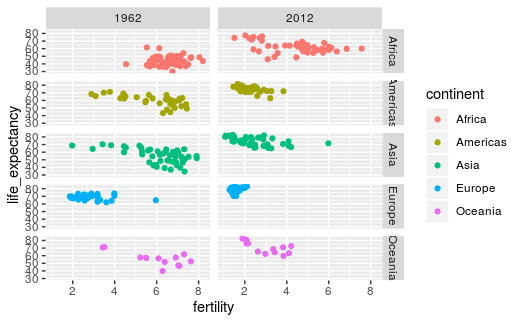

```r
filter(gapminder, year %in% c(1962, 2012)) %>%
  ggplot(aes(fertility, life_expectancy, col = continent)) +
  geom_point() +
  facet_grid(continent~year)
```

We see a plot for each continent/year pair. However, this is just an example and more than what we want, which is simply to compare 1962 and 2012.

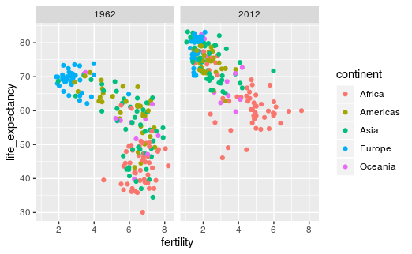

```r
filter(gapminder, year%in%c(1962, 2012)) %>%
  ggplot(aes(fertility, life_expectancy, col = continent)) +
  geom_point() +
  facet_grid(. ~ year)
```

### 10.3.1 `facet_wrap`

To explore how this transformation happened through the years, we can make the plot for several years. The function `facet_wrap` permits us to do this by automatically wrapping the series of plots:

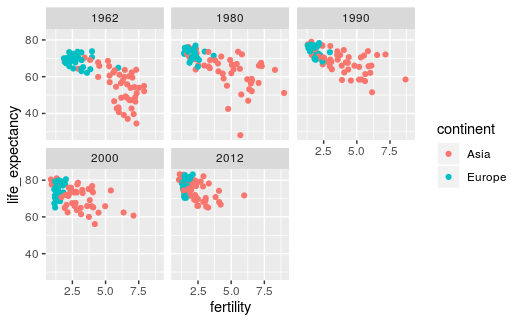

```r
years <- c(1962, 1980, 1990, 2000, 2012)
continents <- c("Europe", "Asia")
gapminder %>%
  filter(year %in% years & continent %in% continents) %>%
  ggplot( aes(fertility, life_expectancy, col = continent)) +
  geom_point() +
  facet_wrap(~year)
```

### 10.3.2 Fixed scales for better comparisons

The default choice of the range of the axes is important. When not using facet, this range is determined by the data shown in the plot. When using `facet`, this range is determined by the data shown in all plots and therefore kept fixed across plots.

## 10.4 Time series plots

Time series plots have time in the x-axis and an outcome or measurement of interest on the y-axis:

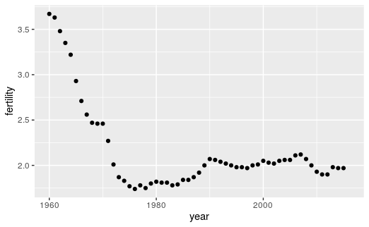

```r
gapminder %>%
  filter(country == "United States") %>%
  ggplot(aes(year, fertility)) +
  geom_point()
```

When the points are regularly and densely spaced, as they are here, we create curves by joining the points with lines. To do this, we use the `geom_line` function instead of `geom_point`.

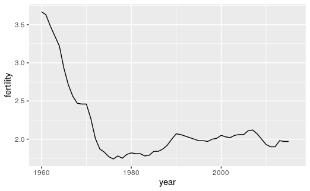

```r
gapminder %>%
  filter(country == "United States") %>%
  ggplot(aes(year, fertility)) +
  geom_line()
```

If we subset the data to include two countries, one from Europe and one from Asia, then adapt the code above:

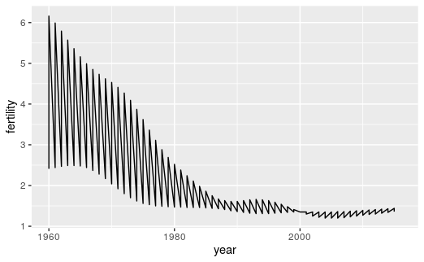

```r
countries <- c("South Korea","Germany")

gapminder %>% filter(country %in% countries) %>%
  ggplot(aes(year,fertility)) +
  geom_line()
```

This is not the plot that we want. To let ggplot know that there are two curves that need to be made separately, we assign each point to a `group`, one for each country:

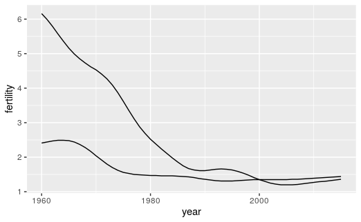

```r
countries <- c("South Korea","Germany")

gapminder %>% filter(country %in% countries & !is.na(fertility)) %>%
  ggplot(aes(year, fertility, group = country)) +
  geom_line()
```

And we can add color to distinct two nation:

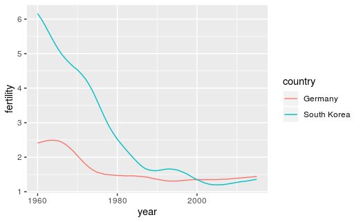

```r
countries <- c("South Korea","Germany")

gapminder %>% filter(country %in% countries & !is.na(fertility)) %>%
  ggplot(aes(year,fertility, col = country)) +
  geom_line()
```

### 10.4.1 Labels instead of legends

We can write labels instead of using legends:

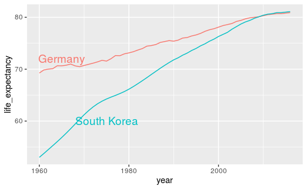

```r
labels <- data.frame(country = countries, x = c(1975,1965), y = c(60,72))

gapminder %>%
  filter(country %in% countries) %>%
  ggplot(aes(year, life_expectancy, col = country)) +
  geom_line() +
  geom_text(data = labels, aes(x, y, label = country), size = 5) +
  theme(legend.position = "none")
```

## 10.5 Data transformations

We now shift our attention to the second question related to the commonly held notion that wealth distribution across the world has become worse during the last decades. The GDP per person is often used as a rough summary of a country’s wealth. Using current US dollars as a unit, a person surviving on an income of less than $2 a day is defined to be living in absolute poverty.

```r
gapminder <- gapminder %>%
  mutate(dollars_per_day = gdp/population/365)
```

### 10.5.1 Log transformation

Here is a histogram of per day incomes from 1970:

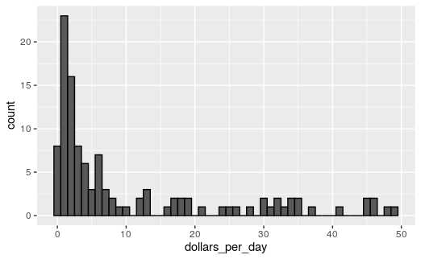

```r
past_year <- 1970
gapminder %>%
  filter(year == past_year & !is.na(gdp)) %>%
  ggplot(aes(dollars_per_day)) +
  geom_histogram(binwidth = 1, color = "black")
```

And we convert type of x axis into log scale. Here is the distribution if we apply a log base 2 transform:

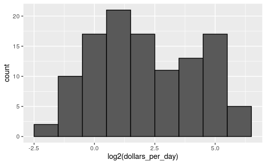

```r
gapminder %>%
  filter(year == past_year & !is.na(gdp)) %>%
  ggplot(aes(log2(dollars_per_day))) +
  geom_histogram(binwidth = 1, color = "black")
```

### 10.5.2 Which base?

We use base of 2 at 10.5.1. But, we might find the better one. So, we would glance the data:

```r
filter(gapminder, year == past_year) %>%
  summarize(min = min(population), max = max(population))
```

| min | max |
| --- | --- |
| 46075 | 808510713 |

And it might be better to use base 10.

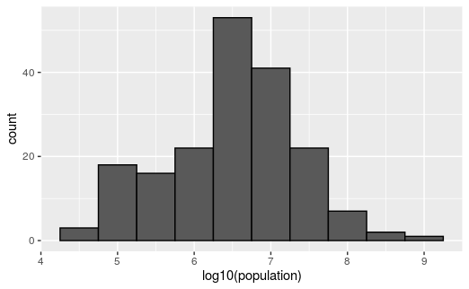

```r
gapminder %>%
  filter(year == past_year) %>%
  ggplot(aes(log10(population))) +
  geom_histogram(binwidth = 0.5, color = "black")
```

### 10.5.3 Transform the values or the scale?

Log is convenient to plot the data, but we cannot read that at once, we need one more step to calculate. So, if we want to scale the axis with logs, we can use the `scale_x_continuous` function.

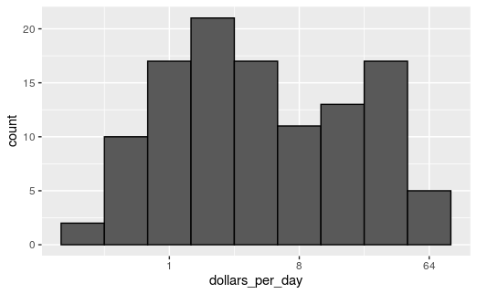

```r
gapminder %>%
  filter(year == past_year & !is.na(gdp)) %>%
  ggplot(aes(dollars_per_day)) +
  geom_histogram(binwidth = 1, color = "black") +
  scale_x_continuous(trans = "log2")
```

If the base was 10 there is the function `scale_x_log10()`:

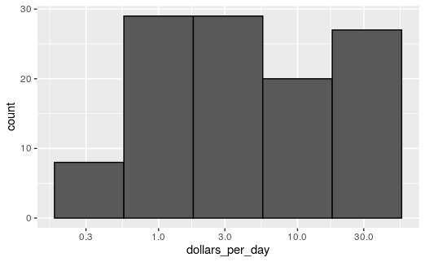

```r
gapminder %>%
  filter(year == past_year & !is.na(gdp)) %>%
  ggplot(aes(dollars_per_day)) +
  geom_histogram(binwidth = 0.5, color = "black") +
  scale_x_log10()
```

There are other transformations available through the `trans` argument like `sqrt`, `logit`, `reverse`, and so on.

## 10.6 Visualizing multimodal distributions

In statistics these bumps are sometimes referred to as modes. When a distribution, like the one above, doesn’t monotonically decrease from the mode, we call the locations where it goes up and down again local modes and say that the distribution has multiple modes.

## 10.7 Comparing multiple distributions with boxplots and ridge plots

Let’s start by quickly examining the data by region.

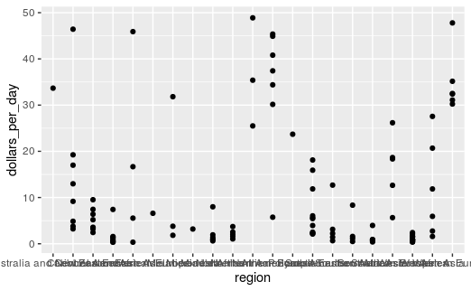

```r
p <- gapminder %>%
  filter(year == past_year & !is.na(gdp)) %>%
  ggplot(aes(region, dollars_per_day))
p + geom_point()
```

To look the name of region, we can use the layer of `theme`:

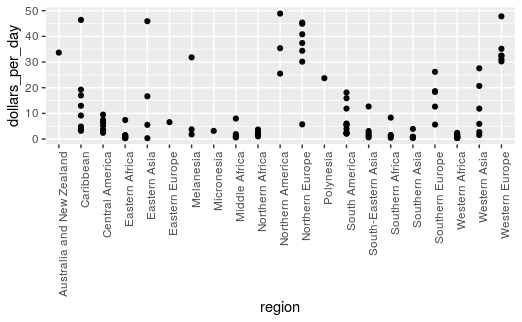

```r
p + geom_point() +
  theme(axis.text.x = element_text(angle = 90, hjust = 1))
```

Data exploration is often made easier if we order the strata by some interpretable quantity. This can be achieved using the `reorder` function:

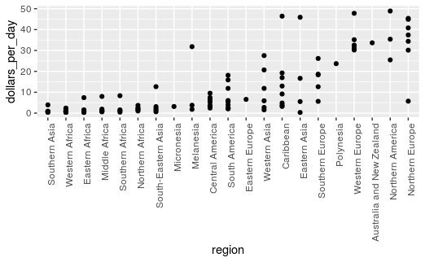

```r
p <- gapminder %>%
  filter(year == past_year & !is.na(gdp)) %>%
  mutate(region = reorder(region, dollars_per_day, FUN = median)) %>%
  ggplot(aes(region, dollars_per_day)) +
  geom_point() +
  theme(axis.text.x = element_text(angle = 90, hjust = 1))
p
```

And it will be nicer to change scale of y axis to logarithm:

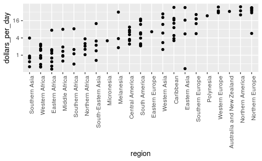

```r
p + scale_y_continuous(trans = "log2")
```

### 10.7.1 Boxplots

Before we make boxplots, we want to merge groups by continetal:

```r
gapminder <- gapminder %>%
  mutate(group = case_when(
    region %in% c("Western Europe", "Northern Europe","Southern Europe",
                    "Northern America", "Australia and New Zealand") ~ "West",
    region %in% c("Eastern Asia", "South-Eastern Asia") ~ "East Asia",
    region %in% c("Caribbean", "Central America", "South America") ~ "Latin America",
    continent == "Africa" & region != "Northern Africa" ~ "Sub-Saharan Africa",
    TRUE ~ "Others"))
```

And we would make the column `group` as a factor:

```r
gapminder <- gapminder %>%
  mutate(group = factor(group,
                        levels = c("Others", "Latin America", "East Asia", "Sub-Saharan Africa", "West")))
```

Finally, we plot this by `group`:

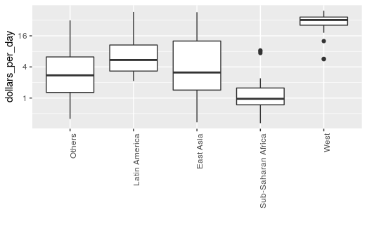

```r
p <- gapminder %>%
  filter(year == past_year & !is.na(gdp)) %>%
  ggplot(aes(group, dollars_per_day)) +
  geom_boxplot() +
  theme(axis.text.x = element_text(angle = 90, hjust = 1)) +
  scale_y_continuous(trans = "log2") +
  xlab("")
p
```

Boxplots have the limitation that by summarizing the data into five numbers. but we can show the data:

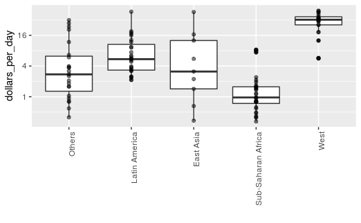

```r
p + geom_point(alpha = 0.5)
```

### 10.7.2 Ridge plots

Boxplot often loses many important data when we convert data into boxxplot. So, this time we will use *ggridges* package:

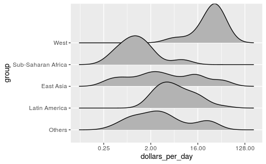

```r
# install.packages("ggridges")

library(ggridges)
p <- gapminder %>%
  filter(year == past_year & !is.na(dollars_per_day)) %>%
  ggplot(aes(dollars_per_day, group)) +
  scale_x_continuous(trans = "log2")
p  + geom_density_ridges()
```

Also, we can point the data:

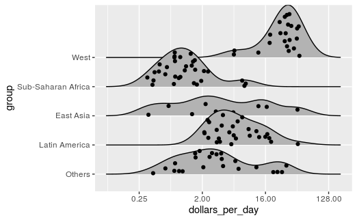

```r
p + geom_density_ridges(jittered_points = TRUE)
```

Or we can add ‘rog representation’:

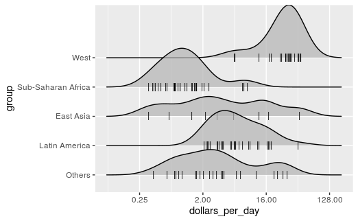

```r
p + geom_density_ridges(jittered_points = TRUE,
                        position = position_points_jitter(width = 0.05, height = 0),
                        point_shape = '|', point_size = 3, point_alpha = 1, alpha = 0.7)
```

### 10.7.3 Example: 1970 versus 2010 income distributions

Data exploration clearly shows that in 1970 there was a “west versus the rest” dichotomy. But does this dichotomy persist? To start, we will focus on two groups: the west and the rest:

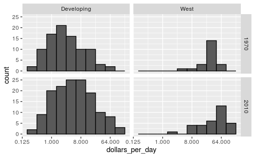

```r
past_year <- 1970
present_year <- 2010
gapminder %>%
  filter(year %in% c(past_year, present_year) & !is.na(gdp)) %>%
  mutate(west = ifelse(group == "West", "West", "Developing")) %>%
  ggplot(aes(dollars_per_day)) +
  geom_histogram(binwidth = 1, color = "black") +
  scale_x_continuous(trans = "log2") +
  facet_grid(year ~ west)
```

We notice that there are more countries represented in the 2010 histograms than in 1970: the total counts are larger. We remake the plots using only countries with data available for both years using the `intersect` function:

```r
country_list_1 <- gapminder %>%
  filter(year == past_year & !is.na(dollars_per_day)) %>%
  pull(country)

country_list_2 <- gapminder %>%
  filter(year == present_year & !is.na(dollars_per_day)) %>%
  pull(country)

country_list <- intersect(country_list_1, country_list_2)
```

Now, we can remake the historgram:

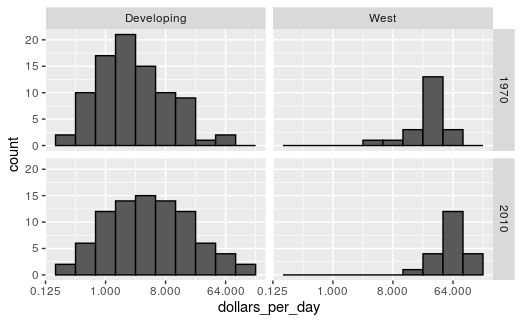

```r
past_year <- 1970
present_year <- 2010
gapminder %>%
  filter(year %in% c(past_year, present_year) & !is.na(gdp) & country %in% country_list) %>%
  mutate(west = ifelse(group == "West", "West", "Developing")) %>%
  ggplot(aes(dollars_per_day)) +
  geom_histogram(binwidth = 1, color = "black") +
  scale_x_continuous(trans = "log2") +
  facet_grid(year ~ west)
```

It seems that income of both groups are increased. So, we can compare them with boxplot:

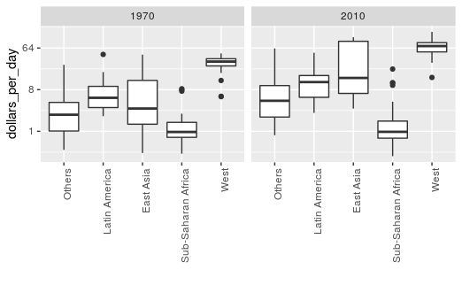

```r
gapminder %>%
  filter(year %in% c(past_year, present_year) & country %in% country_list) %>%
  ggplot(aes(group, dollars_per_day)) +
  geom_boxplot() +
  theme(axis.text.x = element_text(angle = 90, hjust = 1)) +
  scale_y_continuous(trans = "log2") +
  xlab("") +
  facet_grid(. ~ year)
```

It looks little uncomfortable. We want to compare income difference over time by each group:

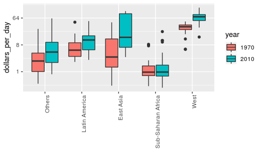

```r
gapminder %>%
  filter(year %in% c(past_year, present_year) & country %in% country_list) %>%
  mutate(year = factor(year)) %>%
  ggplot(aes(group, dollars_per_day, fill = year)) +
  geom_boxplot() +
  theme(axis.text.x = element_text(angle = 90, hjust = 1)) +
  scale_y_continuous(trans = "log2") +
  xlab("")
```

Let’s start by noting that density plots for income distribution in 1970 and 2010 deliver the message that the gap is closing:

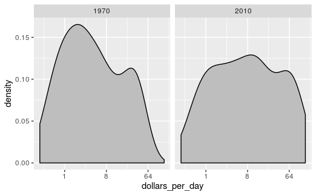

```r
gapminder %>%
  filter(year %in% c(past_year, present_year) & country %in% country_list) %>%
  ggplot(aes(dollars_per_day)) +
  geom_density(fill = "grey") +
  scale_x_continuous(trans = "log2") +
  facet_grid(. ~ year)
```

But there is a problem. The population of two group is different:

```r
gapminder %>%
  filter(year %in% c(past_year) & country %in% country_list) %>%
  count(group)
```

| group | n |
| --- | --- |
| Others | 20 |
| Latin America | 26 |
| East Asia | 9 |
| Sub-Saharan Africa | 32 |
| West | 21 |

So, populations of ‘Developing’ is 87, ‘West’ is 21.

When we depart them:

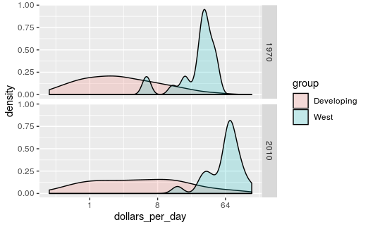

```r
gapminder %>%
  filter(year %in% c(past_year, present_year) & country %in% country_list) %>%
  mutate(group = ifelse(group == "West", "West", "Developing")) %>%
  ggplot(aes(dollars_per_day, fill = group)) +
  scale_x_continuous(trans = "log2") +
  geom_density(alpha = 0.2) +
  facet_grid(year ~ .)
```

But this might make the misunderstandings as two group includes same number of nations.